# Projet 2 : VaR et backtesting, Action UNH

## 1.4) Asymétrie perte/gain, queues de distribution épaisses:

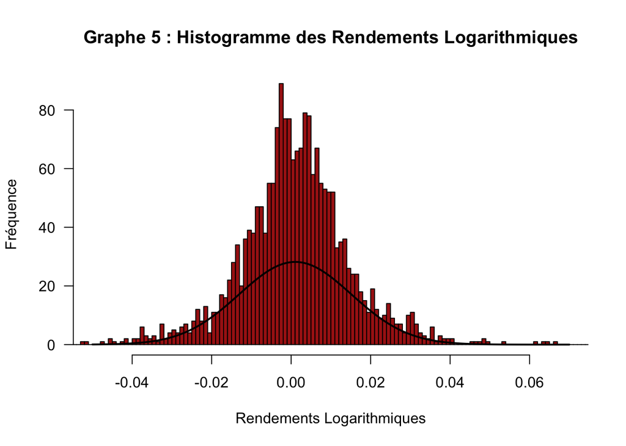

Une première observation est que nos données semblent être symétriques et leptokurtiques. Vérifions-les à l’aide des tests d’Agostino et d’Anscombe.

**Test d’Agostino :**

Un test de l’hypothèse de symétrie consiste à vérifier la nullité de la skewness, qui est égale au moment centré d’ordre 3 normalisé de la distribution. Soit $\mu_3$, le moment centré d’ordre 3 d’une variable aléatoire : $\mu_3 = E[(X - \mu)^3]$. Nous souhaitons tester si la skewness est nulle.

Les hypothèses pour ce test sont les suivantes :

- $H_0$ : La skewness de la distribution est nulle, c’est-à-dire } $\mu_3 = 0$.
- $H_a$ : La skewness de la distribution n’est pas nulle, c’est-à-dire } $\mu_3 \neq 0$

```
    D'Agostino skewness test

data:  rte
skew = -0.05976, z = -1.09822, p-value = 0.2721
alternative hypothesis: data have a skewness
```

On a une p-value = 0.2721 > 0.05 donc $H_0$ est accepté, la skewness de la distribution est nulle. Notre distribution est donc symétrique

**Test d’Anscombe Modifié par Agostino et Zar (Ticket UNH) :**

Le test d’Anscombe modifié par Agostino et Zar est utilisé pour vérifier si les rendements suivent une distribution leptokurtique. Les hypothèses pour ce test sont les suivantes :

- $H_0$ : Les rendements suivent une loi normale centrée réduite (distribution normale)
- $H_a$ : Les rendements ne suivent pas une loi normale centrée réduite (distribution non normale leptokurtique).

Le test d’Anscombe modifié par Agostino et Zar repose sur la statistique qui suit, sous $H_0$, une loi normale centrée réduite. Une valeur de kurtosis significativement différente de 3 est utilisée pour déterminer si la distribution est leptokurtique.

```
    Anscombe-Glynn kurtosis test

data:  rte
kurt = 6.0314, z = 12.1864, p-value < 2.2e-16
alternative hypothesis: kurtosis is not equal to 3
```

Ici, nous avons une valeur de kurtosis (kurt) égale à 6.034, qui est supérieure à 3, et donc significative. Notre distribution est effectivement leptokurtique.

Nos observations préliminaires sont donc confirmées. En fin de compte, nous avons une distribution à la fois symétrique et leptokurtique, ce qui indique une concentration autour de la moyenne et une probabilité accrue d’événements extrêmes (queues épaisses).